# Заработная плата населения России (взаимно-оцениваемое задание: RMLS)

### Описание начальных данных

- источник данных работы: «Российский мониторинг экономического положения и здоровья населения НИУ ВШЭ (RLMS-HSE)», проводимый Национальным исследовательским университетом - Высшей школой экономики и ЗАО «Демоскоп» при участии Центра народонаселения Университета Северной Каролины в Чапел Хилле и Института социологии РАН. (Сайты обследования RLMS-HSE: http://www.hse.ru/rlms, http://www.cpc.unc.edu/projects/rlms)». Данные взяты из репрезентативной выборки по индивидам за 2013 год - волна 22 (файл r22i_os25a.sav).
- из всего массива данных отобраны очищенные от пропущенных значений переменные:

```r
library("rlms")

# чтение данных из файла
rd <- read.rlms("./r22i_os25a.sav")

# год проведения опроса для вычисления возраста
year <- 2013

# отбор нужных данных
ed <- data.frame("salary" = rd$rj13.2, "age" = year - rd$rh6,
                 "gender" = as.integer(factor(rd$rh5)) - 1,
                 "education" = factor(rd$r_diplom),
                 "area" = rd$psu, "settlement.status" = rd$status,
                 "staff" = replace(rd$rj6.0, is.na(rd$rj6.0), 0))

# очистка от пропущенных значений
ed <- na.omit(ed)
```

```
1. rj13.2   - среднемесячная заработная плата,

2. rh6      - год рождения,

3. rh5      - пол (ЖЕНСКИЙ/МУЖСКОЙ),

4. r_diplom - образование:
```

```r
# только для отображения значений образования
levels(ed$education)
```

```
## [1] "окончил 0 - 6 классов"
## [2] "незаконч среднее образование (7 - 8 кл)"
## [3] "незаконч среднее образование (7 - 8 кл) + что-то еще"
## [4] "законч среднее образование"
## [5] "законч среднее специальное образование"
## [6] "законч высшее образование и выше"
## [7] "ЗАТРУДНЯЮСЬ ОТВЕТИТЬ"
## [8] "ОТКАЗ ОТ ОТВЕТА"
## [9] "НЕТ ОТВЕТА"
```

```
5. psu      - номер региона (будет интересовать только отношение Москва/не Москва),

6. status   - тип населённого пункта (областной центр, город, ПГТ, село),

7. rj6.0    - количество подчинённых.
```

- в дальнейшем исследовании участвуют только респонденты, давшие полные ответы.

```r
index <-
    ed$education %in% c('окончил 0 - 6 классов', 'незаконч среднее образование (7 - 8 кл)',
                    'незаконч среднее образование (7 - 8 кл) + что-то еще',
                    'законч среднее образование', 'законч среднее специальное образование',
                    'законч высшее образование и выше')

ed <- ed[index, ]
```

### Обработка данных для исследования

Мы будем исследовать зависимость уровня заработной платы `salary` от следующих регрессоров:

- возраст (численный). Соотнесён с переменной `age`.
- пол (качественный). Соотнесён с фиктивной переменной `gender`, где 0 - мужской и 1 - женский.
- образование (качественный). В выборке этот регрессор принимает значения от 1 до 6. Однако разница влияния, к примеру, получения образования в виде 7-8 классов по сравнению с 0-6 классами явно отличается от разницы получения высшего образования по сравнению со средним специальным образованием, хотя оба примера - соседние категории. Поэтому рационально значения этой переменной заменить на 4 категории и ввести в набор данных четыре фиктивных (dummy) переменных `edu1`, `edu2`, `edu3`, `edu4`:

```r
ed$edu1 = as.integer(ed$education %in% c('окончил 0 - 6 классов',
                          'незаконч среднее образование (7 - 8 кл)',
                          'незаконч среднее образование (7 - 8 кл) + что-то еще'))
ed$edu2 = as.integer(ed$education == 'законч среднее образование')
ed$edu3 = as.integer(ed$education == 'законч среднее специальное образование')
ed$edu4 = as.integer(ed$education == 'законч высшее образование и выше')
```

```
                                                    edu1   edu2   edu3   edu4
1. незаконченное среднее образование (1 до 3)         1      0      0      0
2. законченное среднее образование (4)                0      1      0      0
3. законченное среднее специальное образование (5)    0      0      1      0
4. законченное высшее образование (6)                 0      0      0      1
```

Дополнительно добавим в модель два регрессора:

- тип населённого пункта (качественный). Очевидно, что доход работника зависит от места нахождения того или иного предприятия. Здесь выделим отдельно Москву, так как доходы в среднем в Москве значительно превышают доходы в среднем по России. Тогда получим 5 категорий с соответствующими значениями фиктивных переменных (в этом случае закодируем вторым способом, когда все нулевые значения фиктивных переменных первых четырёх категорий означают пятую категорию):

```r
ed$set1 = as.integer(ed$area != 'г. Москва' & ed$settlement.status == 'областной центр')
ed$set2 = as.integer(ed$area != 'г. Москва' & ed$settlement.status == 'город')
ed$set3 = as.integer(ed$area != 'г. Москва' & ed$settlement.status == 'ПГТ')
ed$set4 = as.integer(ed$area != 'г. Москва' & ed$settlement.status == 'село')
```

```
                                                     sel1    sel2    sel3   sel4
1. областной центр                                     1       0       0      0
2. город                                               0       1       0      0
3. посёлок городского типа                             0       0       1      0
4. село                                                0       0       0      1
5. Москва                                              0       0       0      0
```

- количество подчинённых (численный). Вероятно, что с увеличением количества подчинённых возрастает ответственность занимаемой должности, что должно в свою очередь сказаться на доходе в сторону увеличения. Соотнесён с переменной `staff`.

```r
# итоговые данные модели
data <- data.frame('salary'=ed$salary, 'age'=ed$age, 'gender'=ed$gender,
                   'edu1'=ed$edu1, 'edu2'=ed$edu2, 'edu3'=ed$edu3, 'edu4'=ed$edu4,
                   'set1'=ed$set1, 'set2'=ed$set2, 'set3'=ed$set3, 'set4'=ed$set4,
                   'staff'=ed$staff)

# удаление из памяти лишних объектов
rm(rd, ed)
```

Окончательно получим набор данных, состоящий из 12 переменных и 6071 записей.

### Описательные статистики

Предварительно посмотрим на статистическую информацию по полученным данным.

- для количественных переменных рассмотрим минимальное значение переменной `min`, максимальное значение `max`, среднее значение `mean`, медиану `median` и стандартное отклонение `st. dev.`:

```r
# только для наглядного отображения статистик численных переменных
data.frame('статистика'=c('min', 'max', 'mean', 'median', 'st. dev.'),
           'зарплата'=c(min(data$salary), max(data$salary), mean(data$salary),
                        median(data$salary), sqrt(var(data$salary))),
           'возраст'=c(min(data$age), max(data$age), mean(data$age),
                        median(data$age), sqrt(var(data$age))),
           'подчинённые'=c(min(data$staff), max(data$staff), mean(data$staff),
                median(data$staff), sqrt(var(data$staff))) )
```

```
##   статистика  зарплата  возраст подчинённые
## 1        min      0.00 17.00000    0.000000
## 2        max 300000.00 87.00000 1200.000000
## 3       mean  19790.87 41.71323    2.970351
## 4     median  16000.00 41.00000    0.000000
## 5   st. dev.  15944.25 12.62160   22.903410
```

- для качественных переменных подобная статистическая информация мало наглядна (например, не применимо понятие среднего значения, поскольку вычисление среднего предполагает сложение, а операция сложения для таких переменных не определена). Поэтому приведём таблицы соотношений каждого показателя к зарплате (на какие части от общей суммы дохода, равной 120150349, делит то или иное значение показателя):
  1. пол:

```r
    xtabs(formula=salary~gender, data=data)
```

```
## gender
##        0        1
## 64878297 55272052
```

```
2. образование:
```

```r
    ft <- xtabs(formula=salary~edu1 + edu2 + edu3 + edu4, data=data)
    ftable(ft)
```

```
##                edu4        0        1
## edu1 edu2 edu3
## 0    0    0                0 48980995
##           1         29879043        0
##      1    0         33292777        0
##           1                0        0
## 1    0    0          7997534        0
##           1                0        0
##      1    0                0        0
##           1                0        0
```

```
3. тип населённого пункта:
```

```r
    ft <- xtabs(formula=salary~set1 + set2 + set3 + set4, data=data)
    ftable(ft)
```

```
##                set4        0        1
## set1 set2 set3
## 0    0    0         17463800 20035853
##           1          6662600        0
##      1    0         33023675        0
##           1                0        0
## 1    0    0         42964421        0
##           1                0        0
##      1    0                0        0
##           1                0        0
```

```r
# только для показа расчёта показателей для сравнения
moscow_salary <- data[data$set4 + data$set3 + data$set2 + data$set1==0, ]$salary
total_salary <- data$salary
central_salary <- data[data$set1==1, ]$salary

m_t_l <- round(length(moscow_salary) / length(total_salary) * 100, 2)
m_t_s <- round(sum(moscow_salary) / sum(total_salary) * 100, 2)
c_t_l <- round(length(central_salary) / length(total_salary) * 100, 2)
c_t_s <- round(sum(central_salary) / sum(total_salary) * 100, 2)
```

[output not shown]

### Графики

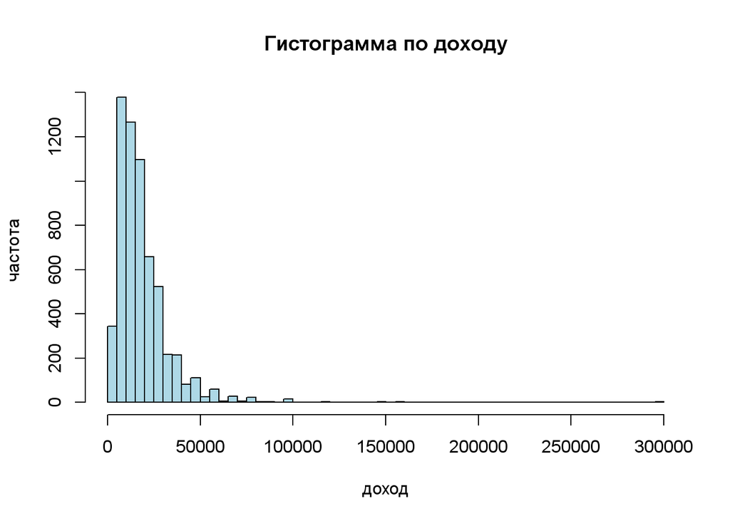

```r
hist(data$salary, main='Гистограмма по доходу', xlab='доход', ylab='частота',
     breaks = 50, col = "lightblue")
```

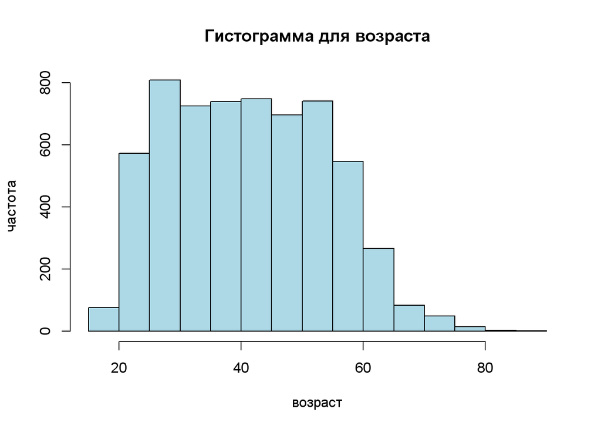

```r
hist(data$age, main='Гистограмма для возраста', xlab='возраст', ylab='частота',
     breaks = 10, col = "lightblue")
```

Из этого же графика можно судить, что выборкой охвачены в целом все возрасты работающих.

### Построение модели

Итак, переходим к построению линейной модели зависимости зарплаты от рассмотренных выше регрессоров методом наименьших квадратов (для образования за базовую категорию возьмём самый низкий уровень).

```r
# построение модели
model <- lm(salary~age + gender + edu2 + edu3 + edu4 + set1 + set2 + set3 + set4 + staff, data=data)
```

Построенная модель имеет следующую таблицу характеристик:

```r
# итоговые характеристики модели
summary(model)
```

```
##
## Call:
## lm(formula = salary ~ age + gender + edu2 + edu3 + edu4 + set1 +
##     set2 + set3 + set4 + staff, data = data)
##
## Residuals:
##    Min     1Q Median     3Q    Max
## -40823  -7192  -2035   4406 285941
##
## Coefficients:
##               Estimate Std. Error t value Pr(>|t|)
## (Intercept)  38201.382   1055.391  36.196  < 2e-16 ***
## age            -83.379     14.389  -5.795 7.19e-09 ***
## gender       -7859.974    371.372 -21.165  < 2e-16 ***
## edu2          2106.870    692.130   3.044  0.00234 **
## edu3          4214.498    709.922   5.937 3.07e-09 ***
## edu4          9540.597    703.313  13.565  < 2e-16 ***
## set1        -15934.907    712.947 -22.351  < 2e-16 ***
## set2        -16054.972    731.502 -21.948  < 2e-16 ***
## set3        -16450.080    995.905 -16.518  < 2e-16 ***
## set4        -20258.262    754.431 -26.852  < 2e-16 ***
## staff           68.209      7.933   8.598  < 2e-16 ***
## ---
## Signif. codes:  0 '***' 0.001 '**' 0.01 '*' 0.05 '.' 0.1 ' ' 1
##
## Residual standard error: 14060 on 6060 degrees of freedom
## Multiple R-squared:  0.224,  Adjusted R-squared:  0.2227
## F-statistic: 174.9 on 10 and 6060 DF,  p-value: < 2.2e-16
```

Все переменные оказались значимыми на уровне 5% (`age`, `gender`, `edu2`, `edu3`, `edu4`, `set1`, `set2`, `set3`, `set4`, `staff`). Значения коэффициентов в целом совпадают с предварительными ожиданиями, а именно:

- возраст: вносит усреднёно незначительную долю, так как в выборке оказалось примерное равное количество всех возрастов работающих. Отрицательное значение скорее объясняется тем, что начиная с определённого возраста работодатель всё реже готов принять такого нового сотрудника, что снижает его стоимость.
- пол: (вспомним, что у нас значение 1 означает женский пол) получаем, что зарплата женщин при прочих равных заметно ниже, чем у мужчин.
- образование: более высокий уровень образования заметно влияет в сторону увеличения дохода.
- тип населённого пункта: значение и знак коэффициента подтверждают нашу гипотезу о том, что в Москве доходы значительно превышают доходы по России (ведь когда все переменные `set1`, `set2`, `set3`, `set4` равны 0, это соответствует респонденту из Москвы). Так же видна положительная зависимость зарплаты от уровня значения населённого пункта.
- количество подчинённых: любопытно, что в данной модели эта переменная оказывает наименьшее влияние на итоговый доход. Здесь явно следует провести дополнительное исследование, и скорее всего, в данном случае мы имеем дело с ‘выбросом’. Построим график с распределением зарплаты по количеству подчинённых:

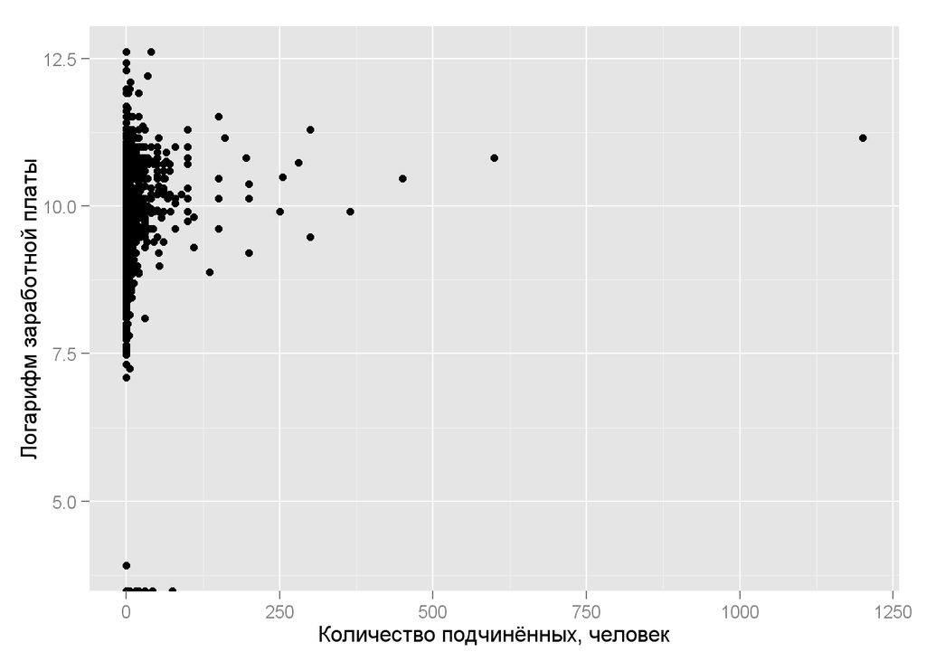

```r
# подключение необходимых библиотек
library('ggplot2')

# график с распределением зарплаты (логарифма) по количеству подчинённых
qplot(data=data, staff, log(salary),
      xlab="Количество подчинённых, человек", ylab="Логарифм заработной платы")
```

Действительно, наблюдается довольно сильный ‘выброс’.

### Модель с робастными ошибками

Теперь построим аналогичную модель, используя робастные ошибки.

```r
# подключение необходимых библиотек
library('sandwich')
library('lmtest')

# расчёт коэффициентов с робастными ошибками
robust_model <- coeftest(model, vcov.=vcovHC(model, type="HC4"))
```

Рассмотрим характеристики для коэффициентов модели с робастными ошибками по сравнению с начальной моделью:

```r
# функция для более наглядного отображения значимости коэффициентов на разных уровнях
get_coef_significance <- function(prt) {
    result <- c()
    for (element in prt) {
        if (element < 0.001) {result <- rbind(result, '***')}
        else if (element < 0.01) {result <- rbind(result, '**')}
        else if (element < 0.05) {result <- rbind(result, '.')}
        else if (element < 0.1) {result <- rbind(result, '+')}
        else {result <- rbind(result, '')}
    }
    result
}

# построение сравнительной таблицы
coef_model = coeftest(model)
comparison_table <- data.frame(
    round(coef_model[, 2], 2), round(robust_model[, 2] ,2),
    round(coef_model[, 3], 2), round(robust_model[, 3], 2),
    round(coef_model[, 4], 5), round(robust_model[, 4], 5),
    get_coef_significance(coef_model[, 4]),
    get_coef_significance(robust_model[, 4]))
names(comparison_table) = c('ст ош', 'ст ош_рб', 't ст', 't ст_рб',
              'Pr(>|t|)', 'Pr_рб', 'знач', 'знач_рб')
comparison_table
```

```
##               ст ош ст ош_рб   t ст t ст_рб Pr(>|t|)   Pr_рб знач знач_рб
## (Intercept) 1055.39  1253.64  36.20   30.47  0.00000 0.00000  ***     ***
## age           14.39    13.67  -5.79   -6.10  0.00000 0.00000  ***     ***
## gender       371.37   409.38 -21.16  -19.20  0.00000 0.00000  ***     ***
## edu2         692.13   454.70   3.04    4.63  0.00234 0.00000   **     ***
## edu3         709.92   504.00   5.94    8.36  0.00000 0.00000  ***     ***
## edu4         703.31   593.67  13.57   16.07  0.00000 0.00000  ***     ***
## set1         712.95  1125.04 -22.35  -14.16  0.00000 0.00000  ***     ***
## set2         731.50  1157.10 -21.95  -13.88  0.00000 0.00000  ***     ***
## set3         995.91  1421.56 -16.52  -11.57  0.00000 0.00000  ***     ***
## set4         754.43  1101.00 -26.85  -18.40  0.00000 0.00000  ***     ***
## staff          7.93    52.74   8.60    1.29  0.00000 0.19593  ***
```

Полученные данные позволяют сделать вывод о том, что в результате использования робастных ошибок произошла корректировка значений стандартных ошибок (как и t-статистик). При этом коэффициенты по-прежнему остались значимыми на уровне 5%, за исключением коэффициента при регрессоре, отвечающим за количество подчинённых `staff`. Последний же оказался вовсе незначим. Стандартные ошибки также изменили свое значение, одни в большую сторону (пол, количество подчинённых и тип населённого пункта) - следовательно, можно утверждать, что в исследуемых данных присутствует гетероскедастичность. Другие (возраст и образование) - в меньшую, что позволяет их теперь использовать в исследовании.

В итоге, учитывая результаты оценки составленной модели, остается вопрос об эффективном подборе переменных, влияющих на уровень дохода населения России в целом.